# **Avages**

Tanner Love

## Introduction

The **avages** package includes functions which quickly offer information pertaining to the ages of the professors and lecturers at Williams College in Williamstown, MA in each year from 2004 to 2014. More specifically, avages gives, for each year, the average age of professors and lecturers, the name(s) and age(s) of the youngest and oldest professor(s) and lecturer(s), and a visual display of the distribution of ages. Additionally, avages gives a graphical representation of the change in mean ages from 2004 to 2014.

## Background

Avages’ functions all rely on information about faculty posted by Williams College in its annual Course Catalog (which can be found at http://web.williams.edu/admin/registrar//catalog/archive.html). The avages package contains copies of this information for each year from 2004 to 2014, and it is stored as plain text files in avages’ inst/extdata directory. Avages’ main functions (avg_age, age_hist, oldst, yngst, and age_change) rely on the actions of two subsidiary functions (ages_1 and ages_2) which parse the text from the Course Catalogs and create a vector of ages of professors at Williams College for each year from 2004 to 2013 and 2014, respectively. Avages determines ages operating under the assumption that, on average, professors and lecturers received their undergraduate degrees at age 22. For years 2004 through 2014, Williams posted the year an undergradduate degree was obtained for the vast majority of faculty members, but excluded this information for a handful of faculty. Avages’ functions ignore this handful of faculty in their calculations. Williams College did not publish the years that factulty received degrees in the 2015 Course Catalog, so avages does not consider 2015.

## Subsidiary Functions

From 2004 to 2013, Williams used the same format for posting information about its professors in the Course Catalog (i.e. “Daniel P. Aalberts Associate Professor of Physics B.S. (1989) M.I.T.; Ph.D. (1994) M.I.T.”). Therefore, the same code effectively parses the 2004-2013 catalogs and creates a vector filled with the ages of professors at Williams for each of these years. For 2014, however, Williams changed the style of the facutly information section of the Course Catalogue (to “Daniel P. Aalberts, Professor of Physics, 1989, BS, MA Institute of Technology, 1994, PHD, MA Institute of Technology”). Because the 2014 catalogue reports the year in which the undergraduate degree was obtained *before* the title of the degree (rather than *after*, as in the 2004 through 2013 Course Catalogs), different code is required to parse the 2014 catalog and create a vector filled with the ages of professors at Williams in 2014.

The ages_1 function scans the plain text file pertaining to a given year, identifies the positions of undergradduate degree titles, identifies the positions of years in which undergraduate degrees were obtained (based on the fact that in these Course Catalogs, the year a degree was obtained always appears one word after the degree title), extracts these years into a new vector, converts the years from strings to integers, and then creates a vector of ages (assuming that, on average, undergraduate degrees were obtained at age 22).

The ages_2 function does basically the exact same thing. The differences are that it only scans the plain text file containing professor information for 2014 and that it finds the years undergraduate degrees were obtained based on the fact that in the 2014 Course Catalog, the year a degree was obtained always appears one word before the degree title.

## Main Functions

### Average Ages

Avages contains a function avg_age which returns the average age of professors in a given year. To determine the average age of professors in 2014, for example, call the avg_age function on the integer 2014.

> avg_age(2014)

```
#> [1] 49.27604
```

The avg_age function relies on input from the subsidiary ages_1 and ages_2 functions, and simply finds the mean value of the age vectors these subsidiary functions produce for a given year.

If avg_age is called on an argument that is not an integer on [2004, 2014], avg_age will return an error message.

### Oldest Professors

The oldst function returns the name(s) and age of the oldest professor(s) in a given year. To determine the oldest professor employed at Williams in 2014, for example, call the oldst function on the integer 2014.

> oldst(2014)

```
#> [1] "Charles B. Dew and Donald deB. Beaver, age 78"
```

The oldst function relies on input from the subsidiary ages_1 and ages_2 functions, and finds the maximum value of the age vectors these subsidiary functions produce for a given year.

If oldst is called on an argument that is not an integer on [2004, 2014], oldst will return an error message.

### Youngest Professors

The yngst function returns the name(s) and age of the youngest professor(s) in a given year. To determine the youngest professor employed at Williams in 2014, for example, call the yngst function on the integer 2014.

> yngst(2014)

```
#> [1] "Sarah A. Mirseyedi, age 25"
```

The yngst function relies on input from the subsidiary ages_1 and ages_2 functions, and finds the minimum value of the age vectors these subsidiary functions produce for a given year.

If yngst is called on an argument that is not an integer on [2004, 2014], yngst will return an error message.

### Distribution of Ages

Avages’ age_hist function produces a histogram displaying the frequency of each age in a given year. To generate such a histogram for the year 2014, for example, call age_hist on the integer 2014.

> age_hist(2014)

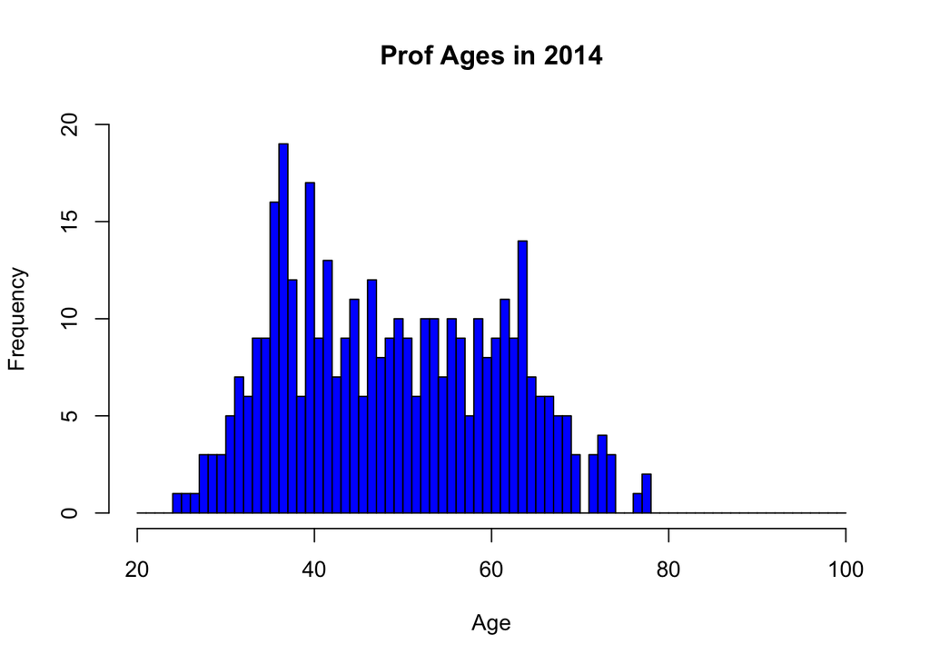

The age_hist function relies on input from the subsidiary ages_1 and ages_2 functions, and produces histograms from the age vectors these subsidiary functions produce for a given year.

### Change in Mean Age Over Time

Avages’ age_change function produces a plot which displays the change in mean age of professors at Williams College from 2004 to 2014. To generate this graph, call the age_change function with no argument.

> age_change()

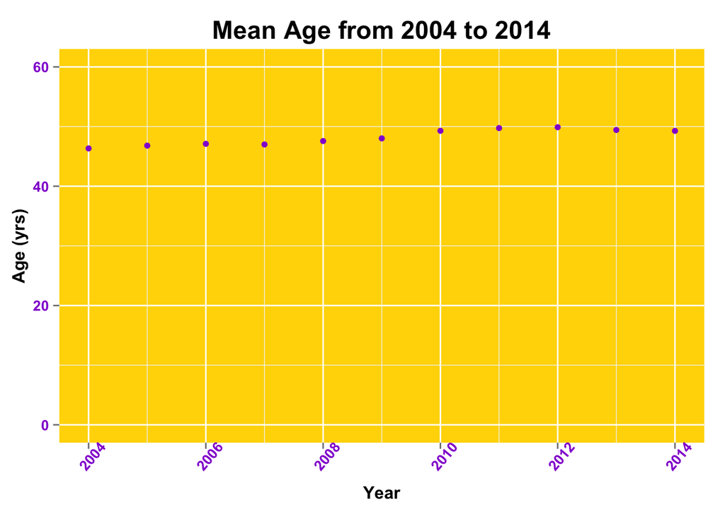

## Avages Results

| Year | Mean Age | Oldest Professor(s) | Youngest Professor(s) |
| --- | --- | --- | --- |
| 2004 | 46.3 | Henry J. Bruton (83) | Zafrir Levy (25) |
| 2005 | 46.8 | Henry J. Bruton (84) | Zafrir Levy (26) |
| 2006 | 47.1 | Henry J. Bruton (85) | Zafrir Levy (27) |
| 2007 | 47.0 | Henry J. Bruton (86) | Robert Michelin (26) |
| 2008 | 47.6 | Henry J. Bruton (87) | Charles N. Howard and Karen Russell (23) |
| 2009 | 48.0 | Henry J. Bruton (88) | Nicholas T. Goodbody (28) |
| 2010 | 49.3 | Henry J. Bruton (89) | Donald Brooks, Marshall K. Creighton, and Christopher Himes (30) |
| 2011 | 49.7 | Henry J. Bruton (90) | Daniel Greenberg (25) |
| 2012 | 49.9 | Henry J. Bruton (91) | Daniel Greenberg (26) |
| 2013 | 49.4 | Henry J. Bruton (92) | Daniel Greenberg (27) |
| 2014 | 49.3 | Charles B. Dew and Donald deB. Beaver (78) | Sarah A. Mirseyedi (25) |